# 6虚拟变量与线性概率模型

LJJ

2020/3/28

The purpose of this in-class lab6 is to practice using **dummy variables** in R. The lab6 should be completed in your group. To get credit, upload your .R script to the appropriate place on Canvas.

## 6.1 For starters

Open up a new R script (named `ICL6_XYZ.R`, where `XYZ` are your initials) and add the usual “preamble” to the top:

```r
# Add names of group members HERE
library(tidyverse)
library(broom)
library(wooldridge)
library(skimr)
library(car)
```

Also install the package `magrittr` by typing **in the console**:

```r
# install.packages("magrittr", repos='http://cran.us.r-project.org')
```

and then add to the preamble of your script

```r
library(magrittr)
```

The `magrittr` package contains extra features for writing even more expressive code.

### 6.1.1 Load the data

We’ll use a new data set on **extramarital affiars**, called `affairs`.

```r
df <- as_tibble(affairs)
df %>% skim()
```

Data summary

| Name | Piped data |
| --- | --- |
| Number of rows | 601 |
| Number of columns | 19 |
| _______________________ |  |
| Column type frequency: |  |
| numeric | 19 |
| ________________________ |  |
| Group variables | None |

**Variable type: numeric**

| skim_variable | n_missing | complete_rate | mean | sd | p0 | p25 | p50 | p75 | p100 | hist |
| --- | --- | --- | --- | --- | --- | --- | --- | --- | --- | --- |
| id | 0 | 1 | 1059.72 | 914.90 | 4.00 | 528 | 1009 | 1453 | 9029 | ▇▁▁▁▁ |
| male | 0 | 1 | 0.48 | 0.50 | 0.00 | 0 | 0 | 1 | 1 | ▇▁▁▁▇ |
| age | 0 | 1 | 32.49 | 9.29 | 17.50 | 27 | 32 | 37 | 57 | ▃▇▂▂▁ |
| yrsmarr | 0 | 1 | 8.18 | 5.57 | 0.12 | 4 | 7 | 15 | 15 | ▆▅▃▃▇ |
| kids | 0 | 1 | 0.72 | 0.45 | 0.00 | 0 | 1 | 1 | 1 | ▃▁▁▁▇ |
| relig | 0 | 1 | 3.12 | 1.17 | 1.00 | 2 | 3 | 4 | 5 | ▂▇▆▇▃ |
| educ | 0 | 1 | 16.17 | 2.40 | 9.00 | 14 | 16 | 18 | 20 | ▁▂▆▇▇ |
| occup | 0 | 1 | 4.19 | 1.82 | 1.00 | 3 | 5 | 6 | 7 | ▅▂▂▇▆ |
| ratemarr | 0 | 1 | 3.93 | 1.10 | 1.00 | 3 | 4 | 5 | 5 | ▁▂▃▇▇ |
| naffairs | 0 | 1 | 1.46 | 3.30 | 0.00 | 0 | 0 | 0 | 12 | ▇▁▁▁▁ |
| affair | 0 | 1 | 0.25 | 0.43 | 0.00 | 0 | 0 | 0 | 1 | ▇▁▁▁▂ |
| vryhap | 0 | 1 | 0.39 | 0.49 | 0.00 | 0 | 0 | 1 | 1 | ▇▁▁▁▅ |
| hapavg | 0 | 1 | 0.32 | 0.47 | 0.00 | 0 | 0 | 1 | 1 | ▇▁▁▁▃ |
| avgmarr | 0 | 1 | 0.15 | 0.36 | 0.00 | 0 | 0 | 0 | 1 | ▇▁▁▁▂ |
| unhap | 0 | 1 | 0.11 | 0.31 | 0.00 | 0 | 0 | 0 | 1 | ▇▁▁▁▁ |
| vryrel | 0 | 1 | 0.12 | 0.32 | 0.00 | 0 | 0 | 0 | 1 | ▇▁▁▁▁ |
| smerel | 0 | 1 | 0.32 | 0.47 | 0.00 | 0 | 0 | 1 | 1 | ▇▁▁▁▃ |
| slghtrel | 0 | 1 | 0.21 | 0.41 | 0.00 | 0 | 0 | 0 | 1 | ▇▁▁▁▂ |
| notrel | 0 | 1 | 0.27 | 0.45 | 0.00 | 0 | 0 | 1 | 1 | ▇▁▁▁▃ |

Check out what’s in the data by typing

```r
glimpse(df)
```

```
## Observations: 601
## Variables: 19
## $ id       <int> 4, 5, 6, 11, 12, 16, 23, 29, 43, 44, 45, 47, 49, 50, 53, 5...
## $ male     <int> 1, 0, 1, 0, 0, 1, 1, 0, 1, 0, 1, 0, 1, 1, 0, 1, 1, 1, 0, 0...
## $ age      <dbl> 37, 27, 27, 32, 27, 57, 22, 32, 37, 22, 57, 32, 22, 37, 32...
## $ yrsmarr  <dbl> 10.000, 4.000, 1.500, 15.000, 4.000, 15.000, 0.750, 1.500,...
## $ kids     <int> 0, 0, 0, 1, 1, 1, 0, 0, 1, 0, 1, 1, 0, 1, 1, 1, 1, 0, 1, 0...
## $ relig    <int> 3, 4, 3, 1, 3, 5, 2, 2, 5, 2, 2, 4, 4, 2, 3, 4, 5, 4, 2, 2...
## $ educ     <int> 18, 14, 18, 12, 17, 18, 17, 17, 18, 12, 14, 16, 14, 20, 17...
## $ occup    <int> 7, 6, 4, 1, 1, 6, 6, 5, 6, 1, 4, 1, 4, 7, 5, 6, 6, 5, 1, 5...
## $ ratemarr <int> 4, 4, 4, 4, 5, 5, 3, 5, 2, 3, 4, 2, 5, 2, 2, 4, 4, 5, 5, 4...
## $ naffairs <int> 0, 0, 3, 0, 3, 0, 0, 0, 7, 0, 0, 0, 0, 0, 12, 0, 0, 1, 1, ...
## $ affair   <int> 0, 0, 1, 0, 1, 0, 0, 0, 1, 0, 0, 0, 0, 0, 1, 0, 0, 1, 1, 0...
## $ vryhap   <int> 0, 0, 0, 0, 1, 1, 0, 1, 0, 0, 0, 0, 1, 0, 0, 0, 0, 1, 1, 0...
## $ hapavg   <int> 1, 1, 1, 1, 0, 0, 0, 0, 0, 0, 1, 0, 0, 0, 0, 1, 1, 0, 0, 1...
## $ avgmarr  <int> 0, 0, 0, 0, 0, 0, 1, 0, 0, 1, 0, 0, 0, 0, 0, 0, 0, 0, 0, 0...
## $ unhap    <int> 0, 0, 0, 0, 0, 0, 0, 0, 1, 0, 0, 1, 0, 1, 1, 0, 0, 0, 0, 0...
## $ vryrel   <int> 0, 0, 0, 0, 0, 1, 0, 0, 1, 0, 0, 0, 0, 0, 0, 0, 1, 0, 0, 0...
## $ smerel   <int> 0, 1, 0, 0, 0, 0, 0, 0, 0, 0, 0, 1, 1, 0, 0, 1, 0, 1, 0, 0...
## $ slghtrel <int> 1, 0, 1, 0, 1, 0, 0, 0, 0, 0, 0, 0, 0, 0, 1, 0, 0, 0, 0, 0...
## $ notrel   <int> 0, 0, 0, 0, 0, 0, 1, 1, 0, 1, 1, 0, 0, 1, 0, 0, 0, 0, 1, 1...
```

You’ll notice that there are a number of variables that only take on 0/1 values: `male`, `kids`, `affair`, `hapavg`, `vryrel`, etc. There are also variables that take on a few different values: `relig`, `occup`, and `ratemarr`.

## 6.2 Creating factor variables

```r
df %<>% mutate(male = factor(male),
               male = fct_recode(male, yes = "1", no = "0"))
```

The `%<>%` operator is shorthand for `df <- df %>% mutate(...)`. In other words, `%<>%` pipes forwards and then pipes everything backwards.

Let’s repeat this for some of the other variables: `ratemarr`, `relig`, `kids`, and `affair`:

```r
df %<>% mutate(ratemarr = factor(ratemarr),
               ratemarr = fct_recode(ratemarr,
                                     very_happy = "5",
                                     happy = "4",
                                     average = "3",
                                     unhappy = "2",
                                     very_unhappy = "1")) %>%
        mutate(relig = factor(relig),
               relig = fct_recode(relig,
                                  very_relig = "5",
                                  relig = "4",
                                  average = "3",
                                  not_relig = "2",
                                  not_at_all_relig = "1")) %>%
        mutate(kids  = factor(kids),
               kids = fct_recode(kids,
                                 yes = "1",
                                 no = "0")) %>%
        mutate(affair = factor(affair),
               affair = fct_recode(affair,
                                   yes = "1",
                                   no = "0"))
```

```r
df %>% DT::datatable()
```

|  | id | male | age | yrsmarr | kids | relig | educ | occup | ratemarr | naffairs | affair | vryhap | hapavg | avgmarr | unhap | vryrel | smerel | slghtrel | notrel |
| --- | --- | --- | --- | --- | --- | --- | --- | --- | --- | --- | --- | --- | --- | --- | --- | --- | --- | --- | --- |
| 1 | 4 | yes | 37 | 10 | no | average | 18 | 7 | happy | 0 | no | 0 | 1 | 0 | 0 | 0 | 0 | 1 | 0 |
| 2 | 5 | no | 27 | 4 | no | relig | 14 | 6 | happy | 0 | no | 0 | 1 | 0 | 0 | 0 | 1 | 0 | 0 |
| 3 | 6 | yes | 27 | 1.5 | no | average | 18 | 4 | happy | 3 | yes | 0 | 1 | 0 | 0 | 0 | 0 | 1 | 0 |
| 4 | 11 | no | 32 | 15 | yes | not_at_all_relig | 12 | 1 | happy | 0 | no | 0 | 1 | 0 | 0 | 0 | 0 | 0 | 0 |
| 5 | 12 | no | 27 | 4 | yes | average | 17 | 1 | very_happy | 3 | yes | 1 | 0 | 0 | 0 | 0 | 0 | 1 | 0 |
| 6 | 16 | yes | 57 | 15 | yes | very_relig | 18 | 6 | very_happy | 0 | no | 1 | 0 | 0 | 0 | 1 | 0 | 0 | 0 |
| 7 | 23 | yes | 22 | 0.75 | no | not_relig | 17 | 6 | average | 0 | no | 0 | 0 | 1 | 0 | 0 | 0 | 0 | 1 |
| 8 | 29 | no | 32 | 1.5 | no | not_relig | 17 | 5 | very_happy | 0 | no | 1 | 0 | 0 | 0 | 0 | 0 | 0 | 1 |
| 9 | 43 | yes | 37 | 15 | yes | very_relig | 18 | 6 | unhappy | 7 | yes | 0 | 0 | 0 | 1 | 1 | 0 | 0 | 0 |
| 10 | 44 | no | 22 | 0.75 | no | not_relig | 12 | 1 | average | 0 | no | 0 | 0 | 1 | 0 | 0 | 0 | 0 | 1 |

[output cut: 591 more lines]

where we used **multiple pipe operators** (`%>%`) to do each factor recode in a separate step. (You could have also put them all into one giant `mutate()` statement.)

Do another `glimpse(df)` to make sure the code worked in the way I told you it would.

### 6.2.1 Summary stats of factor variables

You can look at the frequency of factor variables using the `table()` function:

```r
table(df$ratemarr)
```

```
##
## very_unhappy      unhappy      average        happy   very_happy
##           16           66           93          194          232
```

```r
table(df$relig)
```

```
##
## not_at_all_relig        not_relig          average            relig
##               48              164              129              190
##       very_relig
##               70
```

```r
table(df$ratemarr,df$kids)
```

```
##
##                 no yes
##   very_unhappy   3  13
##   unhappy        8  58
##   average       24  69
##   happy         40 154
##   very_happy    96 136
```

You can also use the `prop.table()` function to get shares within-row (`margin=1`) or within-column (`margin=2`):

```r
table(df$ratemarr) %>% prop.table()
```

```
##
## very_unhappy      unhappy      average        happy   very_happy
##    0.0266223    0.1098170    0.1547421    0.3227953    0.3860233
```

```r
table(df$ratemarr,df$kids) %>% prop.table(margin=1)
```

```
##
##                       no       yes
##   very_unhappy 0.1875000 0.8125000
##   unhappy      0.1212121 0.8787879
##   average      0.2580645 0.7419355
##   happy        0.2061856 0.7938144
##   very_happy   0.4137931 0.5862069
```

```r
table(df$ratemarr,df$kids) %>% prop.table(margin=2)
```

```
##
##                        no        yes
##   very_unhappy 0.01754386 0.03023256
##   unhappy      0.04678363 0.13488372
##   average      0.14035088 0.16046512
##   happy        0.23391813 0.35813953
##   very_happy   0.56140351 0.31627907
```

You can also create a histogram of a factor variable in `ggplot()` as follows:

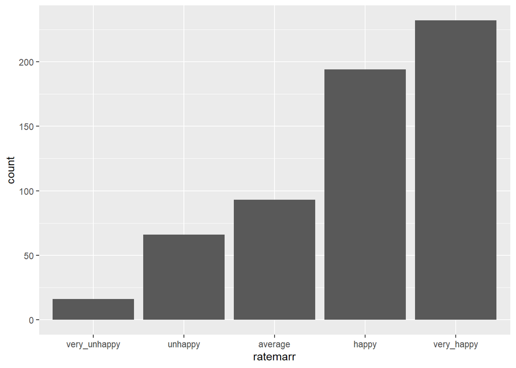

```r
ggplot(df,aes(x=ratemarr)) +
  geom_bar()
```

This helps you visualize what share of the data falls into which category.

## 6.3 Multiple regression with factor variables

Let’s run a regression with `naffairs` as the dependent variable and `male`, `yrsmarr`, `kids`, and `ratemarr` as the covariates.

```r
df %>%
  dplyr::select(male,yrsmarr,kids,ratemarr) %>%
  map(table)
```

```
## $male
##
##  no yes
## 315 286
##
## $yrsmarr
##
##             0.125 0.416999995708466              0.75               1.5
##                11                10                31                88
##                 4                 7                10                15
##               105                82                70               204
##
## $kids
##
##  no yes
## 171 430
##
## $ratemarr
##
## very_unhappy      unhappy      average        happy   very_happy
##           16           66           93          194          232
```

```r
est1 <- lm(naffairs ~ male + yrsmarr + kids + ratemarr, data=df)
```

```r
summary(est1)
```

```
##
## Call:
## lm(formula = naffairs ~ male + yrsmarr + kids + ratemarr, data = df)
##
## Residuals:
##     Min      1Q  Median      3Q     Max
## -4.3742 -1.4138 -0.7915 -0.3155 11.8963
##
## Coefficients:
##                    Estimate Std. Error t value Pr(>|t|)
## (Intercept)         2.93389    0.84458   3.474 0.000551 ***
## maleyes             0.08284    0.25688   0.322 0.747209
## yrsmarr             0.08612    0.02846   3.026 0.002586 **
## kidsyes            -0.21174    0.34867  -0.607 0.543906
## ratemarrunhappy     0.27746    0.87673   0.316 0.751755
## ratemarraverage    -2.13596    0.85369  -2.502 0.012617 *
## ratemarrhappy      -2.27518    0.82104  -2.771 0.005762 **
## ratemarrvery_happy -2.68300    0.82231  -3.263 0.001167 **
## ---
## Signif. codes:  0 '***' 0.001 '**' 0.01 '*' 0.05 '.' 0.1 ' ' 1
##
## Residual standard error: 3.127 on 593 degrees of freedom
## Multiple R-squared:  0.1121, Adjusted R-squared:  0.1016
## F-statistic:  10.7 on 7 and 593 DF,  p-value: 1.017e-12
```

Interpret the coefficient on **`ratemarrvery_happy`**.

## 6.4 Linear Probability Model

Let’s run the same regression as before, but this time use `affair` as the dependent variable. What happens when you run the following code?

```r
est2 <- lm(affair ~ male + yrsmarr + kids + ratemarr, data=df)
est2
```

[output not shown]

R doesn’t want you to run a LPM because R was designed by statisticians who focus more on the “cons” of LPMs than on the “pros.”

To run the LPM, adjust the code by using `as.numeric(affair)` as the dependent variable. Interpret the coefficients on `ratemarraverage` and `kidsyes`.

### 6.4.1 Interaction terms

Finally, let’s run a more flexible model where we allow the effect of fathers and mothers to be different. The way to do this in `lm()` is as follows:

```r
est3 <- lm(as.numeric(affair) ~ male*kids + yrsmarr + ratemarr, data=df)
print(tidy(est3))
```

```
## # A tibble: 9 x 5
##   term                estimate std.error statistic  p.value
##   <chr>                  <dbl>     <dbl>     <dbl>    <dbl>
## 1 (Intercept)         1.39       0.116    12.0     7.09e-30
## 2 maleyes             0.0549     0.0652    0.842   4.00e- 1
## 3 kidsyes             0.0616     0.0594    1.04    3.00e- 1
## 4 yrsmarr             0.00407    0.00382   1.06    2.88e- 1
## 5 ratemarrunhappy     0.000797   0.117     0.00680 9.95e- 1
## 6 ratemarraverage    -0.197      0.114    -1.73    8.45e- 2
## 7 ratemarrhappy      -0.244      0.110    -2.22    2.66e- 2
## 8 ratemarrvery_happy -0.321      0.110    -2.91    3.71e- 3
## 9 maleyes:kidsyes    -0.0216     0.0770   -0.281   7.79e- 1
```

```r
summary(est3)
```

```
##
## Call:
## lm(formula = as.numeric(affair) ~ male * kids + yrsmarr + ratemarr,
##     data = df)
##
## Residuals:
##      Min       1Q   Median       3Q      Max
## -0.54352 -0.26529 -0.17741 -0.06676  0.93070
##
## Coefficients:
##                      Estimate Std. Error t value Pr(>|t|)
## (Intercept)         1.3868488  0.1155082  12.006  < 2e-16 ***
## maleyes             0.0549119  0.0651912   0.842  0.39995
## kidsyes             0.0616286  0.0594000   1.038  0.29992
## yrsmarr             0.0040658  0.0038206   1.064  0.28769
## ratemarrunhappy     0.0007974  0.1173111   0.007  0.99458
## ratemarraverage    -0.1973730  0.1142113  -1.728  0.08448 .
## ratemarrhappy      -0.2441751  0.1098618  -2.223  0.02662 *
## ratemarrvery_happy -0.3205937  0.1100368  -2.914  0.00371 **
## maleyes:kidsyes    -0.0216487  0.0769522  -0.281  0.77856
## ---
## Signif. codes:  0 '***' 0.001 '**' 0.01 '*' 0.05 '.' 0.1 ' ' 1
##
## Residual standard error: 0.4183 on 592 degrees of freedom
## Multiple R-squared:  0.07977,    Adjusted R-squared:  0.06733
## F-statistic: 6.415 on 8 and 592 DF,  p-value: 5.186e-08
```

The coefficient on the **interaction term** is labeled `maleyes:kidsyes`. Do fathers have a differential rate of extramarital affairs compared to mothers?